# Breast Cancer Wisconsin Dataset

Aine

2026-03-05

Loading Libraries:

Loading Dataset:

```r
#Breast Cancer Wisconsin (Diagnostic)
BCWdata <- read.csv("C:wisconsin_dbc.csv")
```

Review Dataset:

```r
BCW <- BCWdata %>%
  dplyr::select(-"ID") %>%                                    # removing the ID
  mutate(malignant = ifelse(Diagnosis == "M", 1, 0)) %>%  #numeric
  dplyr::select(-"Diagnosis")
summary(BCW)
```

```
##   Radius_mean      Texture_mean   Perimeter_mean     Area_mean
##  Min.   : 6.981   Min.   : 9.71   Min.   : 43.79   Min.   : 143.5
##  1st Qu.:11.700   1st Qu.:16.17   1st Qu.: 75.17   1st Qu.: 420.3
##  Median :13.370   Median :18.84   Median : 86.24   Median : 551.1
##  Mean   :14.127   Mean   :19.29   Mean   : 91.97   Mean   : 654.9
##  3rd Qu.:15.780   3rd Qu.:21.80   3rd Qu.:104.10   3rd Qu.: 782.7
##  Max.   :28.110   Max.   :39.28   Max.   :188.50   Max.   :2501.0
##  Smoothness_mean   Compactness_mean  Concavity_mean    Nconcave_mean
##  Min.   :0.05263   Min.   :0.01938   Min.   :0.00000   Min.   :0.00000
##  1st Qu.:0.08637   1st Qu.:0.06492   1st Qu.:0.02956   1st Qu.:0.02031
##  Median :0.09587   Median :0.09263   Median :0.06154   Median :0.03350
##  Mean   :0.09636   Mean   :0.10434   Mean   :0.08880   Mean   :0.04892
##  3rd Qu.:0.10530   3rd Qu.:0.13040   3rd Qu.:0.13070   3rd Qu.:0.07400
##  Max.   :0.16340   Max.   :0.34540   Max.   :0.42680   Max.   :0.20120
##  Symmetry_mean    Fractaldim_mean     Radius_se        Texture_se
##  Min.   :0.1060   Min.   :0.04996   Min.   :0.1115   Min.   :0.3602
##  1st Qu.:0.1619   1st Qu.:0.05770   1st Qu.:0.2324   1st Qu.:0.8339
##  Median :0.1792   Median :0.06154   Median :0.3242   Median :1.1080
##  Mean   :0.1812   Mean   :0.06280   Mean   :0.4052   Mean   :1.2169
##  3rd Qu.:0.1957   3rd Qu.:0.06612   3rd Qu.:0.4789   3rd Qu.:1.4740
##  Max.   :0.3040   Max.   :0.09744   Max.   :2.8730   Max.   :4.8850
##   Perimeter_se       Area_se        Smoothness_se      Compactness_se
##  Min.   : 0.757   Min.   :  6.802   Min.   :0.001713   Min.   :0.002252
##  1st Qu.: 1.606   1st Qu.: 17.850   1st Qu.:0.005169   1st Qu.:0.013080
##  Median : 2.287   Median : 24.530   Median :0.006380   Median :0.020450
##  Mean   : 2.866   Mean   : 40.337   Mean   :0.007041   Mean   :0.025478
##  3rd Qu.: 3.357   3rd Qu.: 45.190   3rd Qu.:0.008146   3rd Qu.:0.032450
##  Max.   :21.980   Max.   :542.200   Max.   :0.031130   Max.   :0.135400
##   Concavity_se      Nconcave_se        Symmetry_se       Fractaldim_se
##  Min.   :0.00000   Min.   :0.000000   Min.   :0.007882   Min.   :0.0008948
##  1st Qu.:0.01509   1st Qu.:0.007638   1st Qu.:0.015160   1st Qu.:0.0022480
##  Median :0.02589   Median :0.010930   Median :0.018730   Median :0.0031870
##  Mean   :0.03189   Mean   :0.011796   Mean   :0.020542   Mean   :0.0037949
##  3rd Qu.:0.04205   3rd Qu.:0.014710   3rd Qu.:0.023480   3rd Qu.:0.0045580
##  Max.   :0.39600   Max.   :0.052790   Max.   :0.078950   Max.   :0.0298400
##  Radius_extreme  Texture_extreme Perimeter_extreme  Area_extreme
##  Min.   : 7.93   Min.   :12.02   Min.   : 50.41    Min.   : 185.2
##  1st Qu.:13.01   1st Qu.:21.08   1st Qu.: 84.11    1st Qu.: 515.3
##  Median :14.97   Median :25.41   Median : 97.66    Median : 686.5
##  Mean   :16.27   Mean   :25.68   Mean   :107.26    Mean   : 880.6
##  3rd Qu.:18.79   3rd Qu.:29.72   3rd Qu.:125.40    3rd Qu.:1084.0
##  Max.   :36.04   Max.   :49.54   Max.   :251.20    Max.   :4254.0
##  Smoothness_extreme Compactness_extreme Concavity_extreme Nconcave_extreme
##  Min.   :0.07117    Min.   :0.02729     Min.   :0.0000    Min.   :0.00000
##  1st Qu.:0.11660    1st Qu.:0.14720     1st Qu.:0.1145    1st Qu.:0.06493
##  Median :0.13130    Median :0.21190     Median :0.2267    Median :0.09993
##  Mean   :0.13237    Mean   :0.25427     Mean   :0.2722    Mean   :0.11461
##  3rd Qu.:0.14600    3rd Qu.:0.33910     3rd Qu.:0.3829    3rd Qu.:0.16140
##  Max.   :0.22260    Max.   :1.05800     Max.   :1.2520    Max.   :0.29100
##  Symmetry_extreme Fractaldim_extreme   malignant
##  Min.   :0.1565   Min.   :0.05504    Min.   :0.0000
##  1st Qu.:0.2504   1st Qu.:0.07146    1st Qu.:0.0000
##  Median :0.2822   Median :0.08004    Median :0.0000
##  Mean   :0.2901   Mean   :0.08395    Mean   :0.3726
##  3rd Qu.:0.3179   3rd Qu.:0.09208    3rd Qu.:1.0000
##  Max.   :0.6638   Max.   :0.20750    Max.   :1.0000
```

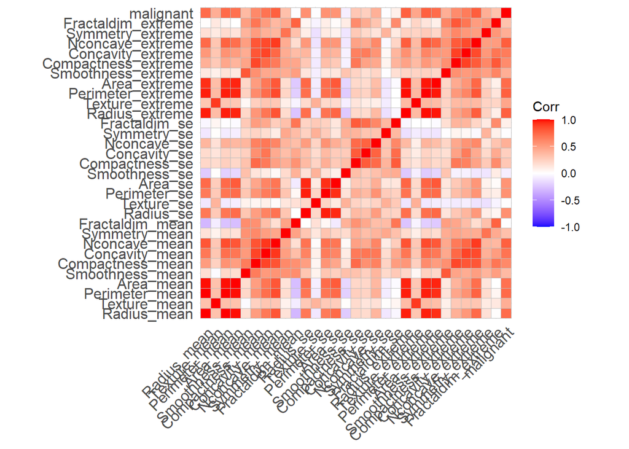

```r
cor_mat <- cor(BCW[sapply(BCW, is.numeric)], use="pairwise.complete.obs")
cor_mat <- as.matrix(cor_mat)
ggcorrplot(cor_mat)
```

```r
correlation = as.data.frame(as.table(cor_mat)) %>%
  mutate(Var1 = as.character(Var1), Var2 = as.character(Var2)) %>% #lets filter duplicates out
  filter(Var1 < Var2) %>% #removes duplicates
  filter(abs(Freq) > 0.7) %>%
  arrange(desc(abs(Freq))) #decending order
kable(correlation, digits = 2, caption = "Correlations greater than .7")
```

Correlations greater than .7

| Var1 | Var2 | Freq |
| --- | --- | --- |
| Perimeter_mean | Radius_mean | 1.00 |
| Perimeter_extreme | Radius_extreme | 0.99 |
| Area_mean | Radius_mean | 0.99 |
| Area_mean | Perimeter_mean | 0.99 |
| Area_extreme | Radius_extreme | 0.98 |
| Area_extreme | Perimeter_extreme | 0.98 |
| Perimeter_se | Radius_se | 0.97 |
| Perimeter_extreme | Perimeter_mean | 0.97 |
| Radius_extreme | Radius_mean | 0.97 |
| Perimeter_mean | Radius_extreme | 0.97 |
| Perimeter_extreme | Radius_mean | 0.97 |
| Area_mean | Radius_extreme | 0.96 |
| Area_extreme | Area_mean | 0.96 |
| Area_mean | Perimeter_extreme | 0.96 |
| Area_se | Radius_se | 0.95 |
| Area_extreme | Perimeter_mean | 0.94 |
| Area_extreme | Radius_mean | 0.94 |
| Area_se | Perimeter_se | 0.94 |
| Concavity_mean | Nconcave_mean | 0.92 |
| Texture_extreme | Texture_mean | 0.91 |
| Nconcave_extreme | Nconcave_mean | 0.91 |
| Compactness_extreme | Concavity_extreme | 0.89 |
| Concavity_extreme | Concavity_mean | 0.88 |
| Compactness_mean | Concavity_mean | 0.88 |
| Compactness_extreme | Compactness_mean | 0.87 |
| Concavity_mean | Nconcave_extreme | 0.86 |
| Nconcave_mean | Perimeter_extreme | 0.86 |
| Concavity_extreme | Nconcave_extreme | 0.86 |
| Nconcave_mean | Perimeter_mean | 0.85 |
| Compactness_mean | Nconcave_mean | 0.83 |
| Nconcave_mean | Radius_extreme | 0.83 |
| Area_mean | Nconcave_mean | 0.82 |
| Nconcave_mean | Radius_mean | 0.82 |
| Nconcave_extreme | Perimeter_extreme | 0.82 |
| Compactness_mean | Concavity_extreme | 0.82 |
| Compactness_mean | Nconcave_extreme | 0.82 |
| Area_extreme | Area_se | 0.81 |
| Compactness_extreme | Fractaldim_extreme | 0.81 |
| Area_extreme | Nconcave_mean | 0.81 |
| Smoothness_extreme | Smoothness_mean | 0.81 |
| Compactness_se | Fractaldim_se | 0.80 |
| Compactness_se | Concavity_se | 0.80 |
| Compactness_extreme | Nconcave_extreme | 0.80 |
| Area_mean | Area_se | 0.80 |
| malignant | Nconcave_extreme | 0.79 |
| Nconcave_extreme | Radius_extreme | 0.79 |
| malignant | Perimeter_extreme | 0.78 |
| malignant | Nconcave_mean | 0.78 |
| malignant | Radius_extreme | 0.78 |
| Concavity_se | Nconcave_se | 0.77 |
| Nconcave_extreme | Perimeter_mean | 0.77 |
| Fractaldim_extreme | Fractaldim_mean | 0.77 |
| Area_se | Perimeter_extreme | 0.76 |
| Area_se | Radius_extreme | 0.76 |
| Compactness_extreme | Concavity_mean | 0.75 |
| Concavity_extreme | Nconcave_mean | 0.75 |
| Area_extreme | Radius_se | 0.75 |
| Area_extreme | Nconcave_extreme | 0.75 |
| Area_se | Perimeter_mean | 0.74 |
| Nconcave_extreme | Radius_mean | 0.74 |
| Compactness_se | Nconcave_se | 0.74 |
| malignant | Perimeter_mean | 0.74 |
| Compactness_mean | Compactness_se | 0.74 |
| Area_se | Radius_mean | 0.74 |
| Area_extreme | malignant | 0.73 |
| Area_mean | Radius_se | 0.73 |
| Area_extreme | Perimeter_se | 0.73 |
| malignant | Radius_mean | 0.73 |
| Concavity_mean | Perimeter_extreme | 0.73 |
| Concavity_se | Fractaldim_se | 0.73 |
| Area_mean | Perimeter_se | 0.73 |
| Area_mean | Nconcave_extreme | 0.72 |
| Perimeter_extreme | Perimeter_se | 0.72 |
| Perimeter_extreme | Radius_se | 0.72 |
| Concavity_mean | Perimeter_mean | 0.72 |
| Radius_extreme | Radius_se | 0.72 |
| Nconcave_mean | Perimeter_se | 0.71 |
| Area_mean | malignant | 0.71 |

```r
total_correlation <- nrow(correlation)
total_correlation
```

```
## [1] 78
```

Split into Test/ Train:

```r
set.seed(321321) #reproducible
n<-nrow(BCW)
train.BCW<-runif(n)<0.7
BCW.test<-BCW[!train.BCW,]
V2.test<-BCW.test$malignant
V2.test.factor <- as.factor(BCW.test$malignant)
```

Create Reproducible Brier Score:

```r
brier_score <- function(y, pred_prob) {
  mean((y - pred_prob)^2)
}
```

## Logistic Regression:

Brier’s Score:

```r
glm.BCW<-glm(malignant ~., data = BCW, subset = train.BCW, family = binomial)
BCW.probs<-predict(glm.BCW, newdata = BCW.test, type = "response")
GLM_Brier = brier_score(V2.test, BCW.probs)
GLM_Brier
```

```
## [1] 0.03488372
```

Confusion Matrix & Accuracy Score:

Threshold: A threshold of .3 was chosen to ensure high sensitivity with respect to specify. A threshold of .3 helps reduce the risk of false negatives which would have devastating consequences with respect to classifying tumors.

Confusion Matrix & Accuracy:

```r
glm.pred <- rep(0, nrow(BCW.test)) #size of the test set.
glm.pred[BCW.probs > 0.3] = 1#.3threshold for classification
table(glm.pred, V2.test)
```

```
##         V2.test
## glm.pred   0   1
##        0 109   2
##        1   4  57
```

```r
GLM.Accuracy = mean(glm.pred == V2.test)
GLM.Accuracy
```

```
## [1] 0.9651163
```

Roc Curve:

```r
roc_obj.glm <- roc(V2.test, BCW.probs)
```

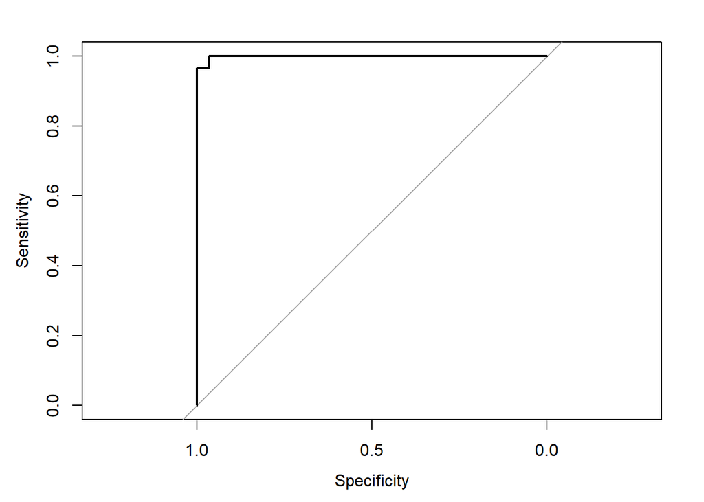

```r
plot(roc_obj.glm, type = "s")
```

```r
GLM.AUC = auc(roc_obj.glm)
GLM.AUC
```

```
## Area under the curve: 0.9654
```

Calibration CUrve:

```
## optimization did not converge for lrm.fit
## Step size  0.0078125  has reduced below minstepsize= 0.01 without improving log likelihood; fitting stopped
## convergence code 1
```

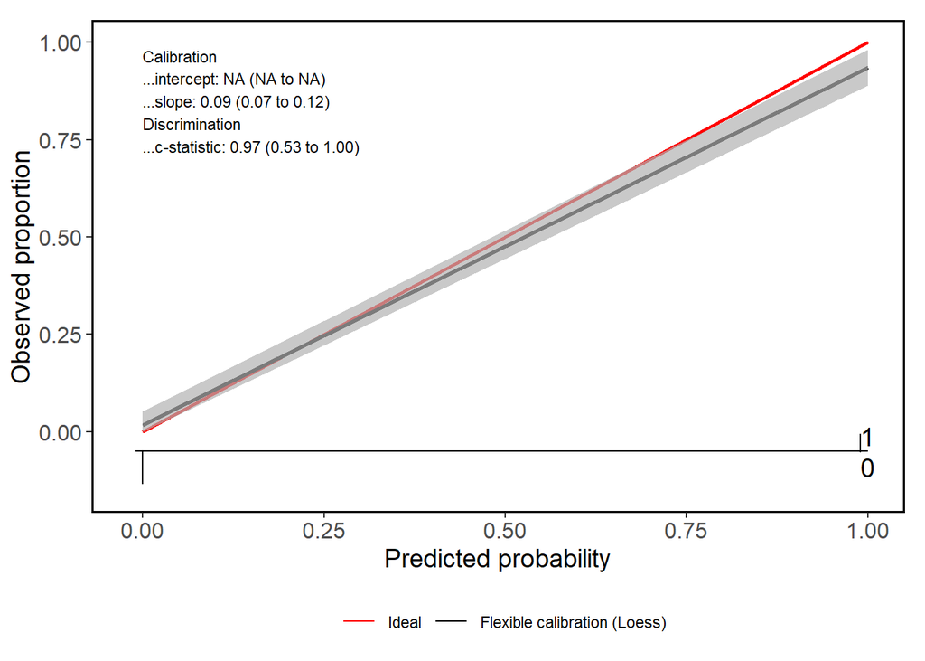

```
## Call:
## valProbggplot(p = BCW.probs, y = V2.test)
##
## A 95% confidence interval is given for the calibration intercept, calibration slope and c-statistic.
##
##          Dxy      C (ROC)           R2            D     D:Chi-sq          D:p
##   0.93070346   0.96535173   0.87247122   0.99210084 171.64134496   0.00000000
##            U     U:Chi-sq          U:p            Q        Brier    Intercept
##   2.21491948 382.96615102   0.00000000  -1.22281864   0.03488372           NA
##        Slope         Emax Brier scaled         Eavg          ECI
##   0.09231802   0.55745033   0.84520774   0.03488372   0.17344832
```

```r
valProbggplot(BCW.probs, V2.test)
```

## Stepwise Appraoches:

```r
set.seed(123)
glm.step <- step(glm.BCW, direction = "both", trace = FALSE) # Stepwise (both forward & backward) selection based on AIC. FALSE= dont see how got to choosen values.
summary(glm.step)
```

```
##
## Call:
## glm(formula = malignant ~ Radius_mean + Texture_mean + Area_mean +
##     Compactness_mean + Concavity_mean + Nconcave_mean + Radius_se +
##     Smoothness_se + Compactness_se + Concavity_se + Nconcave_se +
##     Symmetry_se + Fractaldim_se + Radius_extreme + Smoothness_extreme +
##     Compactness_extreme + Concavity_extreme + Symmetry_extreme +
##     Fractaldim_extreme, family = binomial, data = BCW, subset = train.BCW)
##
## Coefficients:
##                       Estimate Std. Error z value Pr(>|z|)
## (Intercept)         -1.542e+03  8.375e+04  -0.018    0.985
## Radius_mean         -2.151e+03  3.720e+04  -0.058    0.954
## Texture_mean         1.635e+02  2.587e+03   0.063    0.950
## Area_mean            2.272e+01  3.846e+02   0.059    0.953
## Compactness_mean    -3.282e+04  5.396e+05  -0.061    0.952
## Concavity_mean       1.527e+04  2.500e+05   0.061    0.951
## Nconcave_mean        5.398e+04  9.458e+05   0.057    0.954
## Radius_se            3.911e+03  6.308e+04   0.062    0.951
## Smoothness_se       -2.393e+05  3.826e+06  -0.063    0.950
## Compactness_se       1.031e+05  1.629e+06   0.063    0.950
## Concavity_se        -4.363e+04  6.999e+05  -0.062    0.950
## Nconcave_se          1.259e+05  2.010e+06   0.063    0.950
## Symmetry_se         -5.981e+04  9.881e+05  -0.061    0.952
## Fractaldim_se       -9.213e+05  1.459e+07  -0.063    0.950
## Radius_extreme       2.914e+02  5.416e+03   0.054    0.957
## Smoothness_extreme   1.614e+04  2.613e+05   0.062    0.951
## Compactness_extreme -1.211e+04  1.926e+05  -0.063    0.950
## Concavity_extreme    5.347e+03  8.572e+04   0.062    0.950
## Symmetry_extreme     1.086e+04  1.781e+05   0.061    0.951
## Fractaldim_extreme   9.398e+04  1.482e+06   0.063    0.949
##
## (Dispersion parameter for binomial family taken to be 1)
##
##     Null deviance: 5.2931e+02  on 396  degrees of freedom
## Residual deviance: 1.5402e-05  on 377  degrees of freedom
## AIC: 40
##
## Number of Fisher Scoring iterations: 25
```

Brier Score:

```r
step.probs<-predict(glm.step, newdata = BCW.test, type = "response")
step_Brier = brier_score(V2.test, step.probs)
step_Brier
```

```
## [1] 0.02325581
```

Confusion Matrix & Accuracy Score:

```r
BCW.step.pred <- rep(0, nrow(BCW.test)) #size of the test set.
BCW.step.pred[step.probs > 0.3] = 1 #.5threshold for classification
table(BCW.step.pred, V2.test)
```

```
##              V2.test
## BCW.step.pred   0   1
##             0 110   1
##             1   3  58
```

```r
Accuracy.step = mean(BCW.step.pred == V2.test)
Accuracy.step
```

```
## [1] 0.9767442
```

Roc Curve:

```r
roc_obj.step <- roc(V2.test, step.probs)
```

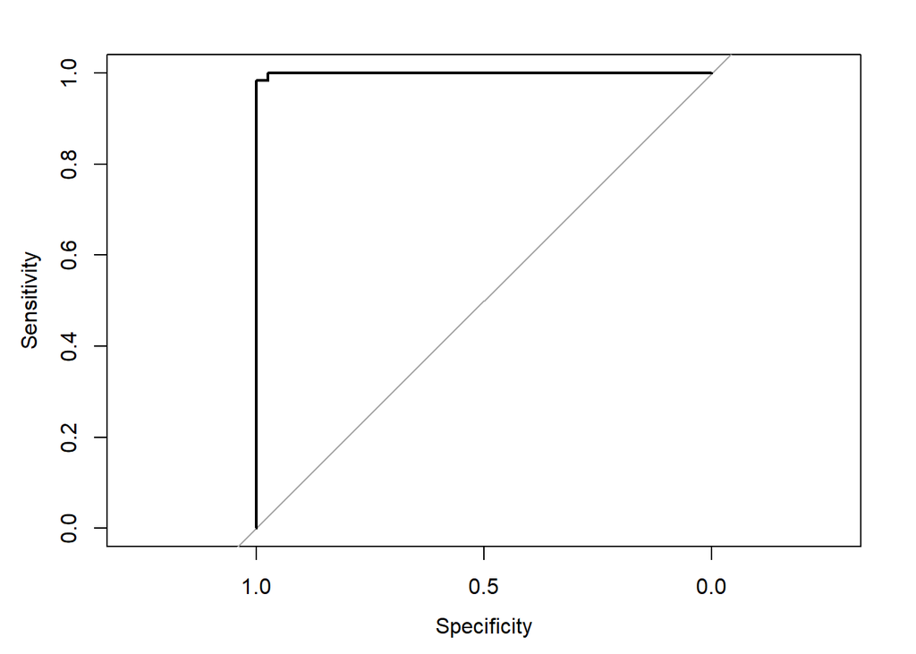

```r
plot(roc_obj.step, type = "s")
```

```r
step.AUC = auc(roc_obj.step)
step.AUC
```

```
## Area under the curve: 0.9783
```

Calibration CUrve:

```
## optimization did not converge for lrm.fit
## Step size  0.0078125  has reduced below minstepsize= 0.01 without improving log likelihood; fitting stopped
## convergence code 1
```

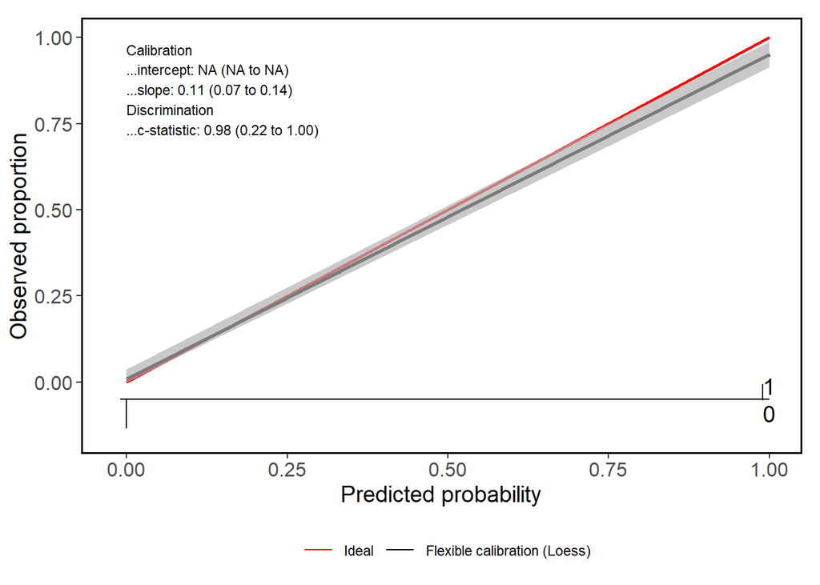

```
## Call:
## valProbggplot(p = step.probs, y = V2.test)
##
## A 95% confidence interval is given for the calibration intercept, calibration slope and c-statistic.
##
##          Dxy      C (ROC)           R2            D     D:Chi-sq          D:p
##   0.95650217   0.97825109   0.91290581   1.07479920 185.86546192   0.00000000
##            U     U:Chi-sq          U:p            Q        Brier    Intercept
##   1.45939334 253.01565442   0.00000000  -0.38459414   0.02325581           NA
##        Slope         Emax Brier scaled         Eavg          ECI
##   0.10629210   0.59273810   0.89680516   0.02325581   0.09101744
```

```r
valProbggplot(step.probs, V2.test)
```

## Ridge Regression:

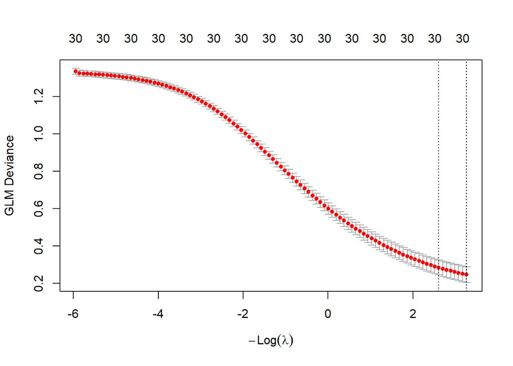

```r
set.seed(123)
x <- model.matrix(malignant ~ ., BCW)[, -1] #make matrixes
y <- BCW$malignant
ridge.mod<-glmnet(x[train.BCW,], y[train.BCW], alpha = 0, family = binomial)
cv.out <- cv.glmnet(x[train.BCW, ], y[train.BCW], alpha = 0, family = binomial)
plot(cv.out)
```

```r
bestlam <- cv.out$lambda.min #May prefer 1-SE not minimum but here minimum.
bestlam
```

```
## [1] 0.03832769
```

```r
#cv.out$lambda.1se?
```

Brier Score:

```r
ridge.probs <- predict(ridge.mod, s = bestlam,newx = x[!train.BCW, ], type = "response")
Ridge_Brier = brier_score(V2.test, ridge.probs)
Ridge_Brier
```

```
## [1] 0.01899515
```

Confusion Matrix & Accuracy Score:

```r
BCW.ridge.pred <- rep(0, nrow(BCW.test)) #size of the test set.
BCW.ridge.pred[ridge.probs > .3] <- 1 #.3threshold for classification
ridge.probs <- as.vector(ridge.probs)
table(BCW.ridge.pred, V2.test)
```

```
##               V2.test
## BCW.ridge.pred   0   1
##              0 108   1
##              1   5  58
```

```r
Accuracy.Ridge = mean(BCW.ridge.pred == V2.test)
Accuracy.Ridge
```

```
## [1] 0.9651163
```

ROC Curve:

```r
roc_obj.ridge <- roc(V2.test, ridge.probs)
```

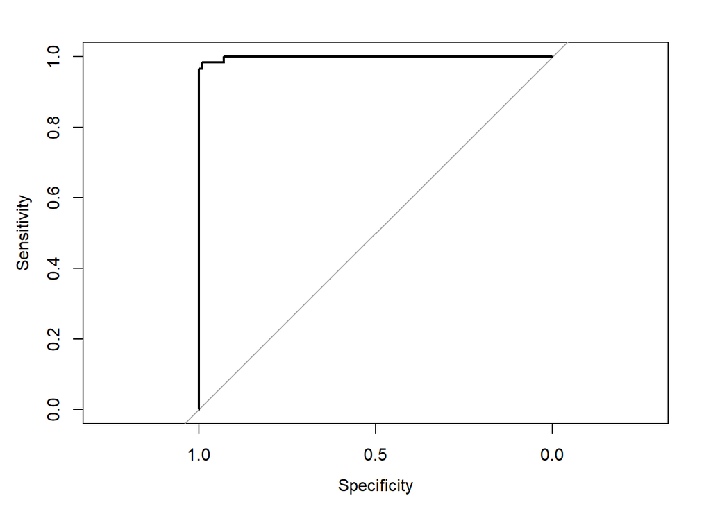

```r
plot(roc_obj.ridge, type = "s")
```

```r
Ridge.AUC = auc(roc_obj.ridge)
Ridge.AUC
```

```
## Area under the curve: 0.9987
```

Calibration Plot:

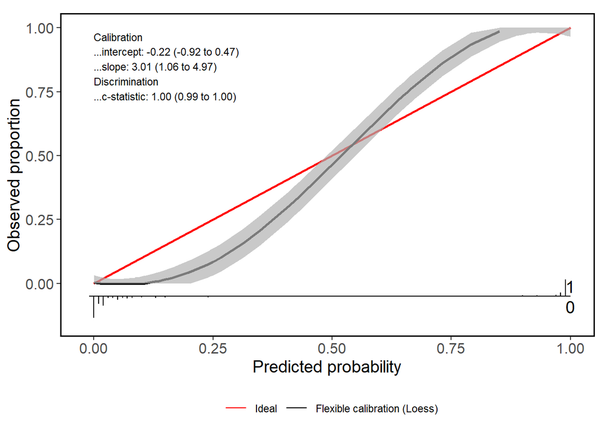

```
## Call:
## valProbggplot(p = ridge.probs, y = V2.test)
##
## A 95% confidence interval is given for the calibration intercept, calibration slope and c-statistic.
##
##           Dxy       C (ROC)            R2             D      D:Chi-sq
##  9.973001e-01  9.986501e-01  9.663441e-01  1.195770e+00  2.066725e+02
##           D:p             U      U:Chi-sq           U:p             Q
##  0.000000e+00  6.881371e-02  1.383596e+01  9.898285e-04  1.126957e+00
##         Brier     Intercept         Slope          Emax  Brier scaled
##  1.899515e-02 -2.223044e-01  3.014396e+00  2.665711e-01  9.157113e-01
##          Eavg           ECI
##  4.091567e-02  4.004702e-01
```

```r
Ridge.calplot<-valProbggplot(ridge.probs, V2.test)
Ridge.calplot
```

## Lasso Model:

```r
set.seed(321321)
lasso.mod<-glmnet(x[train.BCW,], y[train.BCW], alpha = 1, family = binomial)
cv.out <- cv.glmnet(x[train.BCW, ], y[train.BCW], alpha = 1, family = binomial)
```

[output not shown]

[output cut: 154 more lines]

[output not shown]

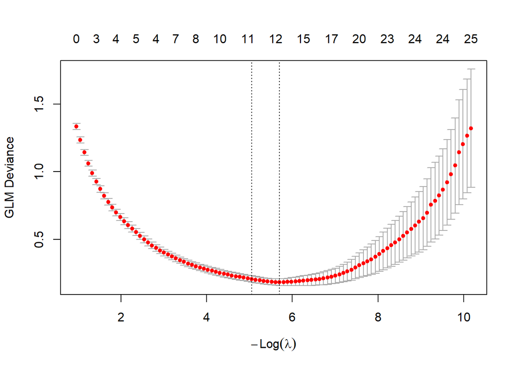

```r
plot(cv.out)
```

```r
bestlam <- cv.out$lambda.min #May prefer 1-SE not minimum but here minimum.
bestlam
```

```
## [1] 0.003333547
```

```r
#cv.out$lambda.1se
Kept <- coef(cv.out, s = "lambda.min")
Kept[Kept[,1] != 0, ]
```

```
##        (Intercept)      Nconcave_mean      Symmetry_mean          Radius_se
##       -28.27164087        19.78024697         0.75702156         8.46947873
##     Compactness_se      Fractaldim_se     Radius_extreme    Texture_extreme
##       -41.41113283      -139.33046881         0.42895650         0.21205314
##  Perimeter_extreme Smoothness_extreme  Concavity_extreme   Nconcave_extreme
##         0.03890922        20.53102750         5.13413876        16.53568208
##   Symmetry_extreme
##         8.29722177
```

Brier’s Score:

```r
lasso.probs <- predict(lasso.mod, s = bestlam,newx = x[!train.BCW, ], type = "response")
lasso_Brier = brier_score(V2.test, ridge.probs)#Ensure factors are 1 & 0.
lasso_Brier
```

```
## [1] 0.01899515
```

Confusion Matrix & Accuracy Score:

```r
BCW.lasso.pred <- rep(0, nrow(BCW.test)) #size of the test set.
BCW.lasso.pred[lasso.probs > .3] <- 1 #.3threshold for classification
table(BCW.lasso.pred, V2.test)
```

```
##               V2.test
## BCW.lasso.pred   0   1
##              0 111   1
##              1   2  58
```

```r
Accuracy.lasso = mean(BCW.lasso.pred == V2.test)
Accuracy.lasso
```

```
## [1] 0.9825581
```

Roc Curve:

```r
roc_obj.lasso <- roc(V2.test, ridge.probs)
```

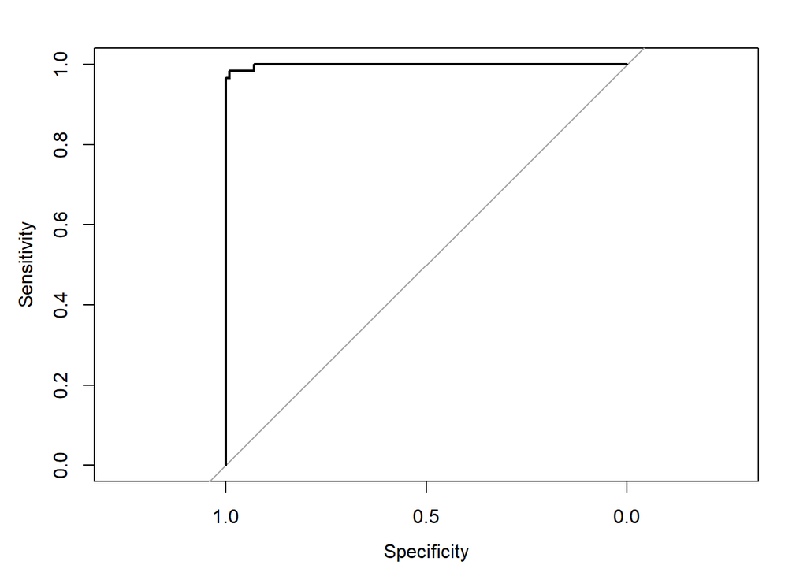

```r
plot(roc_obj.lasso, type = "s")
```

```r
lasso.AUC = auc(roc_obj.lasso)
lasso.AUC
```

```
## Area under the curve: 0.9987
```

Calibration Plot:

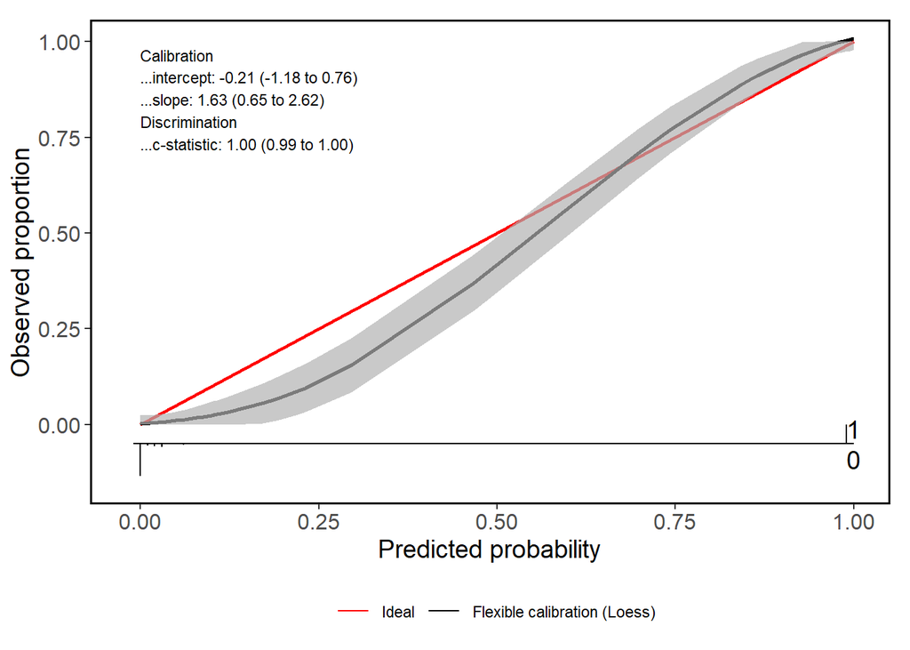

```
## Call:
## valProbggplot(p = lasso.probs, y = V2.test)
##
## A 95% confidence interval is given for the calibration intercept, calibration slope and c-statistic.
##
##           Dxy       C (ROC)            R2             D      D:Chi-sq
##   0.997000150   0.998500075   0.965450637   1.193622578 206.303083345
##           D:p             U      U:Chi-sq           U:p             Q
##   0.000000000   0.005229305   2.899440420   0.234635928   1.188393273
##         Brier     Intercept         Slope          Emax  Brier scaled
##   0.012985545  -0.206453104   1.633638925   0.114009040   0.942378226
##          Eavg           ECI
##   0.016867781   0.105324431
```

```r
Lasso.calplot<-valProbggplot(lasso.probs, V2.test)
Lasso.calplot
```

## Matrix Test/ Train:

```r
set.seed(123)
standardized.X <- scale(BCW[, names(BCW) != "malignant"]) #standardize & sure malignant isnt
Y <- as.factor(BCW$malignant)#y must be a factor in PCA
X <- standardized.X[train.BCW, ]
XTest <- standardized.X[!train.BCW, ]
Ytrain <- Y[train.BCW]
Ytest <- Y[!train.BCW]
Ytest_numeric = as.numeric(as.character(Ytest)) #going factor-numeric causes it to fail
Ytrain_numeric = as.numeric(as.character(Ytrain))
```

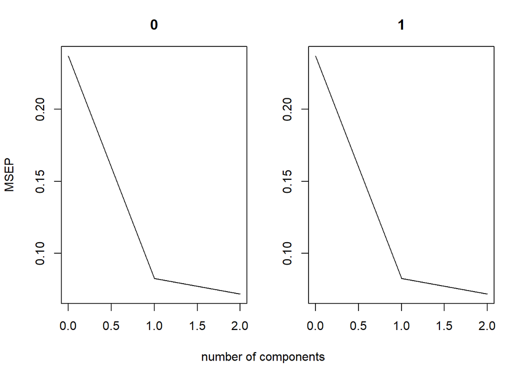

```r
plsda.fit <- plsda(X, Ytrain, cv = TRUE)
validationplot(plsda.fit, val.type = "MSEP")
```

```r
plsda.fit <- plsda(X, Ytrain, ncomp = 1)
plsda.probs <- predict(plsda.fit, newdata = XTest, type = "prob")

prob_M <- plsda.probs[, "1", 1]
Ytest_numeric <- as.numeric(as.character(Ytest))#becuase made y a factor back to numeric

plsda_Brier <- brier_score(Ytest_numeric, prob_M)
plsda_Brier
```

```
## [1] 0.1169014
```

Confusion Matrix & Accuracy Score:

```r
BCW.plsda.pred <- rep(0, length(prob_M))
BCW.plsda.pred[prob_M > 0.3] <- 1
table(BCW.plsda.pred, Ytest)
```

```
##               Ytest
## BCW.plsda.pred  0  1
##              0 47  0
##              1 66 59
```

```r
Accuracy.plsda = mean(BCW.plsda.pred == Ytest)
Accuracy.plsda
```

```
## [1] 0.6162791
```

Roc Curve:

```r
roc_obj.plsda <- roc(Ytest_numeric, prob_M)
```

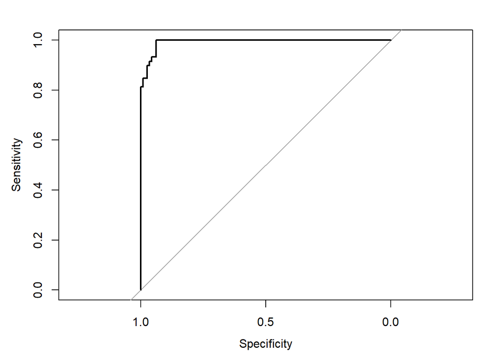

```r
plot(roc_obj.plsda, type = "s")
```

```r
plsda.AUC = auc(roc_obj.plsda)
plsda.AUC
```

```
## Area under the curve: 0.9928
```

Calibration Plot:

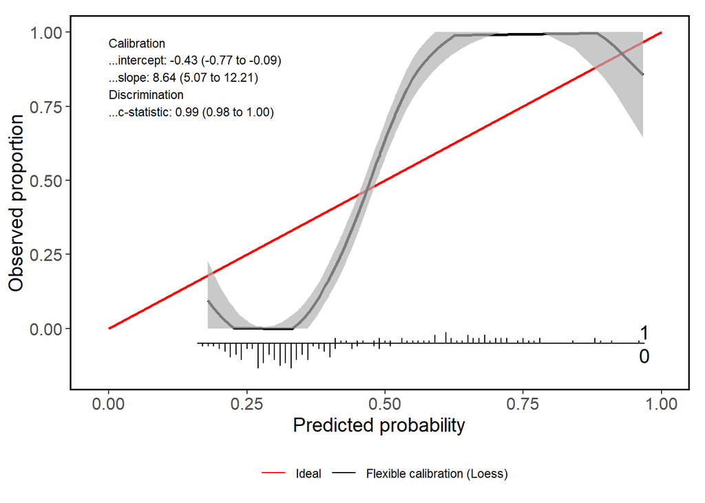

```
## Call:
## valProbggplot(p = prob_M, y = Ytest_numeric)
##
## A 95% confidence interval is given for the calibration intercept, calibration slope and c-statistic.
##
##          Dxy      C (ROC)           R2            D     D:Chi-sq          D:p
##    0.9856007    0.9928004    0.9065375    1.0613122  183.5456939    0.0000000
##            U     U:Chi-sq          U:p            Q        Brier    Intercept
##    0.5867494  102.9209037    0.0000000    0.4745627    0.1169014   -0.4280337
##        Slope         Emax Brier scaled         Eavg          ECI
##    8.6409640    0.4062775    0.4812641    0.2759094    8.3363382
```

```r
plsda.calplot<-valProbggplot(prob_M, Ytest_numeric)
plsda.calplot
```

## Assessment:

```r
results <- data.frame(
  Model = c("Linear Regression", "Best SUbset", "Ridge Model", "Lasso Model", 'PCA Model'),  Accuracy = round(c(GLM.Accuracy,Accuracy.step, Accuracy.Ridge, Accuracy.lasso, Accuracy.plsda), 3),
  Brier = round(c(GLM_Brier, step_Brier, Ridge_Brier, lasso_Brier, plsda_Brier), 3),
  AUC = round(c(GLM.AUC,step.AUC, Ridge.AUC, lasso.AUC, plsda.AUC), 3)
)

best_accuracy <- which.max(results$Accuracy)
best_brier    <- which.min(results$Brier)
best_auc      <- which.max(results$AUC)

results %>%
  kable(caption = "Accuracy, Brier & AUC") %>%
  kable_styling(bootstrap_options = c("striped", "hover"),full_width = FALSE,position = "center") %>%
  column_spec(2, bold = ifelse(1:nrow(results) == best_accuracy, TRUE, FALSE),
              background = ifelse(1:nrow(results) == best_accuracy, "#c6efce", "white")) %>%
  column_spec(3, bold = ifelse(1:nrow(results) == best_brier, TRUE, FALSE),
              background = ifelse(1:nrow(results) == best_brier, "#c6efce", "white")) %>%
  column_spec(4, bold = ifelse(1:nrow(results) == best_auc, TRUE, FALSE),
              background = ifelse(1:nrow(results) == best_auc, "#c6efce", "white"))
```

Accuracy, Brier & AUC

| Model | Accuracy | Brier | AUC |
| --- | --- | --- | --- |
| Linear Regression | 0.965 | 0.035 | 0.965 |
| Best SUbset | 0.977 | 0.023 | 0.978 |
| Ridge Model | 0.965 | 0.019 | 0.999 |
| Lasso Model | 0.983 | 0.019 | 0.999 |
| PCA Model | 0.616 | 0.117 | 0.993 |

## Linear Discriminant Analysis:

```r
lda.fit <- lda(malignant ~., data = BCW, subset = train.BCW)
lda.pred <- predict(lda.fit, BCW.test)
lda.class <- lda.pred$class
lda.probs <- lda.pred$posterior
prob_M <- lda.probs[, 2]
```

Brier’s Score:

```r
lda_Brier <- brier_score(V2.test, prob_M)
lda_Brier
```

```
## [1] 0.01692952
```

Confusion Matrix & Accuracy Score:

```r
BCW.lda.pred <- rep(0, nrow(BCW.test)) #size of the test set.
BCW.lda.pred[prob_M > .3] <- 1 #.5threshold for classification
table(BCW.lda.pred, V2.test)
```

```
##             V2.test
## BCW.lda.pred   0   1
##            0 112   2
##            1   1  57
```

```r
Accuracy.lda = mean(BCW.lda.pred == V2.test)
Accuracy.lda
```

```
## [1] 0.9825581
```

Assessing Results:

```r
summary(prob_M)
```

```
##      Min.   1st Qu.    Median      Mean   3rd Qu.      Max.
## 4.000e-08 9.648e-05 3.125e-03 3.228e-01 9.945e-01 1.000e+00
```

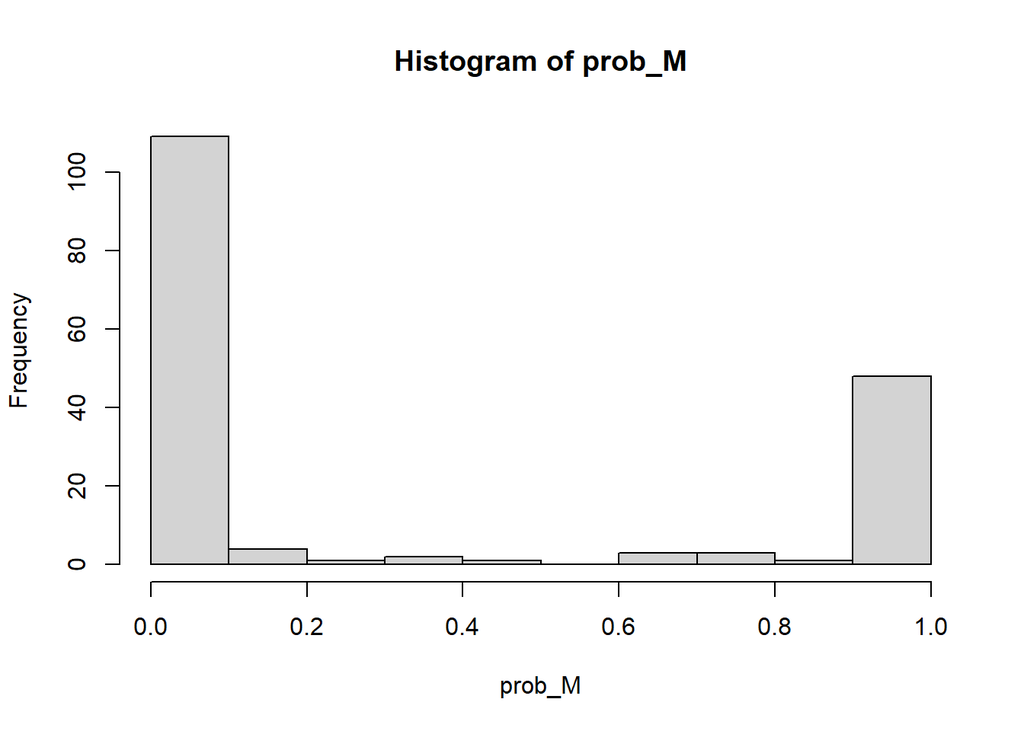

```r
hist(prob_M)
```

Roc Curve:

```r
roc_obj.lda <- roc(V2.test, prob_M)
```

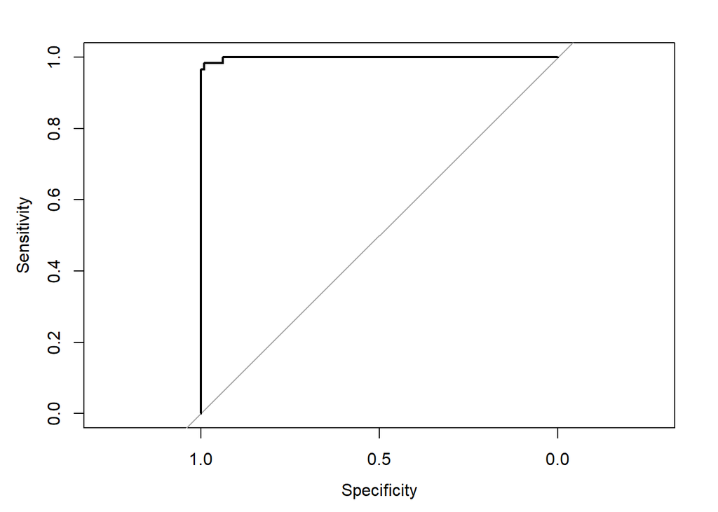

```r
plot(roc_obj.lda, type = "s")
```

```r
lda.AUC = auc(roc_obj.lda)
lda.AUC
```

```
## Area under the curve: 0.9988
```

Calibration Plot:

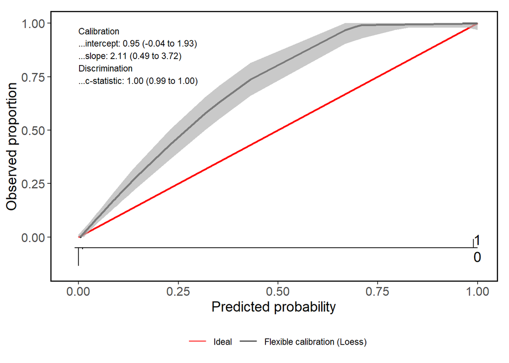

```
## Call:
## valProbggplot(p = prob_M, y = V2.test)
##
## A 95% confidence interval is given for the calibration intercept, calibration slope and c-statistic.
##
##          Dxy      C (ROC)           R2            D     D:Chi-sq          D:p
##   0.99760012   0.99880006   0.97222187   1.21001534 209.12263806   0.00000000
##            U     U:Chi-sq          U:p            Q        Brier    Intercept
##   0.03061056   7.26501707   0.02644975   1.17940477   0.01692952   0.94626516
##        Slope         Emax Brier scaled         Eavg          ECI
##   2.10703469   0.45084140   0.92487731   0.02769997   0.51928300
```

```r
lda.calplot<-valProbggplot(prob_M, V2.test)
lda.calplot
```

## Naive Bayes

```r
nb.fit <- naiveBayes(malignant ~ ., data = BCW, subset = train.BCW) #TEST/ TRAIN SPLIT
```

Brier’s Score:

```r
nb.pred <- predict(nb.fit, BCW.test, type = "raw")  #again predicted on the test set
nb.probs <- nb.pred[, 2]#extracts column of probability=malignant
NB_Brier = brier_score(V2.test, nb.probs)#Ensure factors are 1 & 0.
NB_Brier
```

```
## [1] 0.03812851
```

Confusion Matrix & Accuracy:

```r
nb.class= rep(0, nrow(BCW.test))
nb.class[nb.probs > 0.3] = 1
nb.class <- factor(nb.class, levels = c(0,1))
table(nb.class, V2.test)
```

```
##         V2.test
## nb.class   0   1
##        0 109   3
##        1   4  56
```

```r
NB.Accuracy <- mean(nb.class == V2.test)
NB.Accuracy
```

```
## [1] 0.9593023
```

Assessing Results:

```r
summary(nb.probs)
```

```
##    Min. 1st Qu.  Median    Mean 3rd Qu.    Max.
##  0.0000  0.0000  0.0000  0.3486  1.0000  1.0000
```

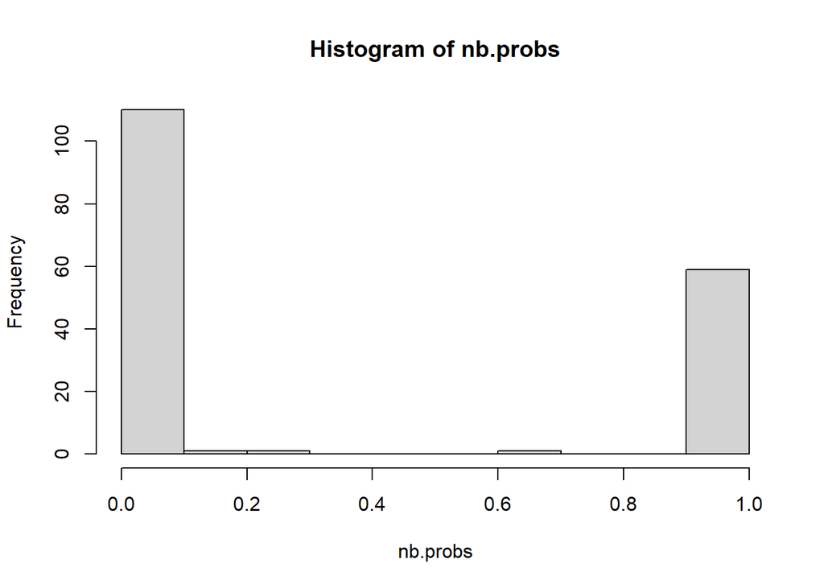

```r
hist(nb.probs)
```

Roc Curve:

```r
roc_obj.NB <- roc(V2.test, nb.probs)
```

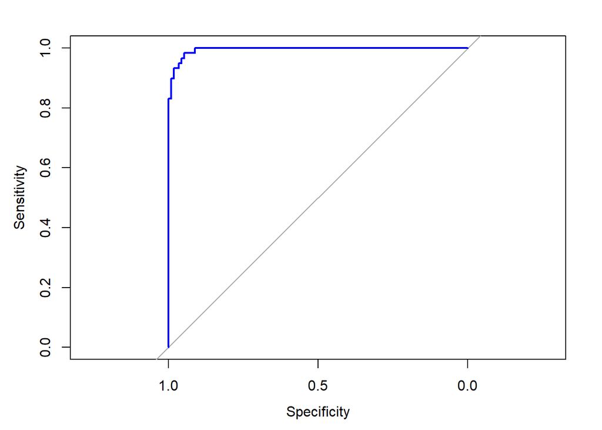

```r
plot(roc_obj.NB, type = "s", col = "blue")
```

```r
NB.AUC = auc(roc_obj.NB)
NB.AUC
```

```
## Area under the curve: 0.9951
```

Calibration Curve:

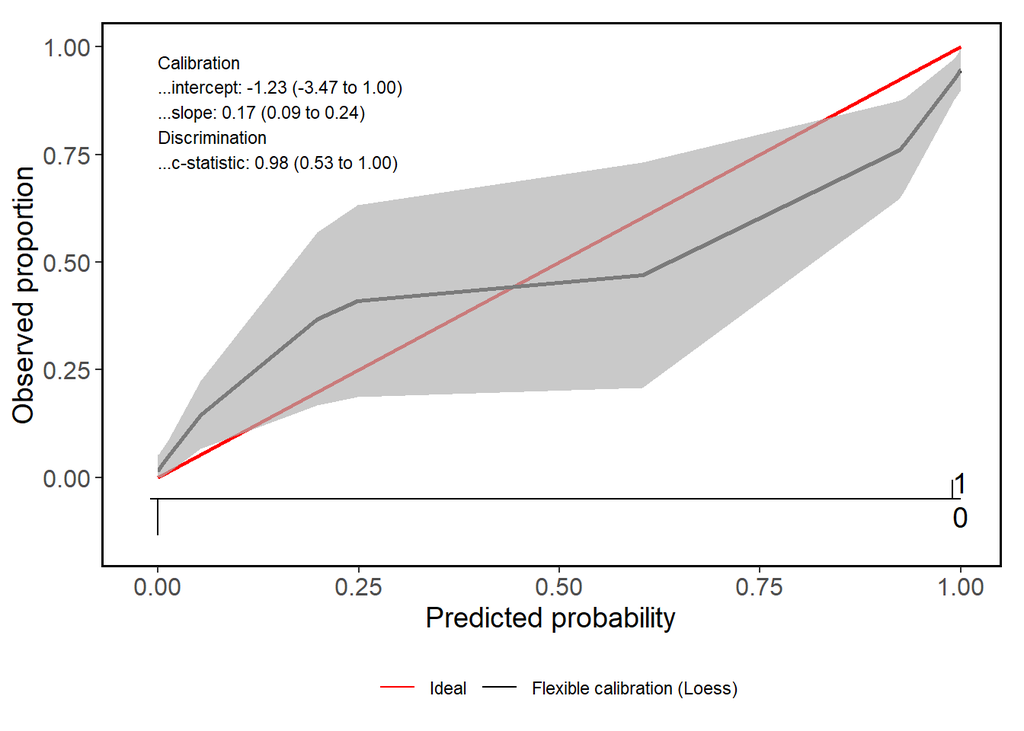

```
## Call:
## valProbggplot(p = nb.probs, y = V2.test)
##
## A 95% confidence interval is given for the calibration intercept, calibration slope and c-statistic.
##
##           Dxy       C (ROC)            R2             D      D:Chi-sq
##  9.610619e-01  9.805310e-01  7.444892e-01  4.751329e-01  6.181702e+01
##           D:p             U      U:Chi-sq           U:p             Q
##  3.774758e-15  5.145669e-01  6.786456e+01  1.887379e-15 -3.943396e-02
##         Brier     Intercept         Slope          Emax  Brier scaled
##  5.123519e-02 -1.233531e+00  1.653276e-01  4.219558e-01  7.726501e-01
##          Eavg           ECI
##  3.395428e-02  1.939516e-01
```

```r
valProbggplot(nb.probs, V2.test)
```

## K-NN

```r
set.seed(123)
k.values <- 1:20 #k can be 1 to 20
cv.error <- rep(NA, 20) #stores misclassification error
for(i in k.values){
  pred <- knn.cv(train = X,cl = Ytrain,k = i) #leave-one-out CV
  cv.error[i] <- mean(pred != Ytrain) #stores misclassification erro
}
best.k <- which.min(cv.error)
best.k
```

```
## [1] 7
```

Brier Score:

```r
knn.fit <- knn(X, XTest, Ytrain, k = 3, prob = TRUE)
knn.probs <- attr(knn.fit, "prob") #knn for classification couldnt use predict?
prob_M <- ifelse(knn.fit == 1, knn.probs, 1 - knn.probs)
knn_Brier = brier_score(Ytest_numeric, prob_M)
knn_Brier
```

```
## [1] 0.02260982
```

Accuracy & Confusion Matrix:

```r
knn.class= rep(0, nrow(BCW.test))
knn.class[prob_M > 0.3] = 1
table(knn.class, Ytest_numeric)
```

```
##          Ytest_numeric
## knn.class   0   1
##         0 105   1
##         1   8  58
```

```r
knn.Accuracy = mean(knn.class==Ytest_numeric)
knn.Accuracy
```

```
## [1] 0.9476744
```

```r
summary(prob_M)
```

```
##    Min. 1st Qu.  Median    Mean 3rd Qu.    Max.
##  0.0000  0.0000  0.0000  0.3295  1.0000  1.0000
```

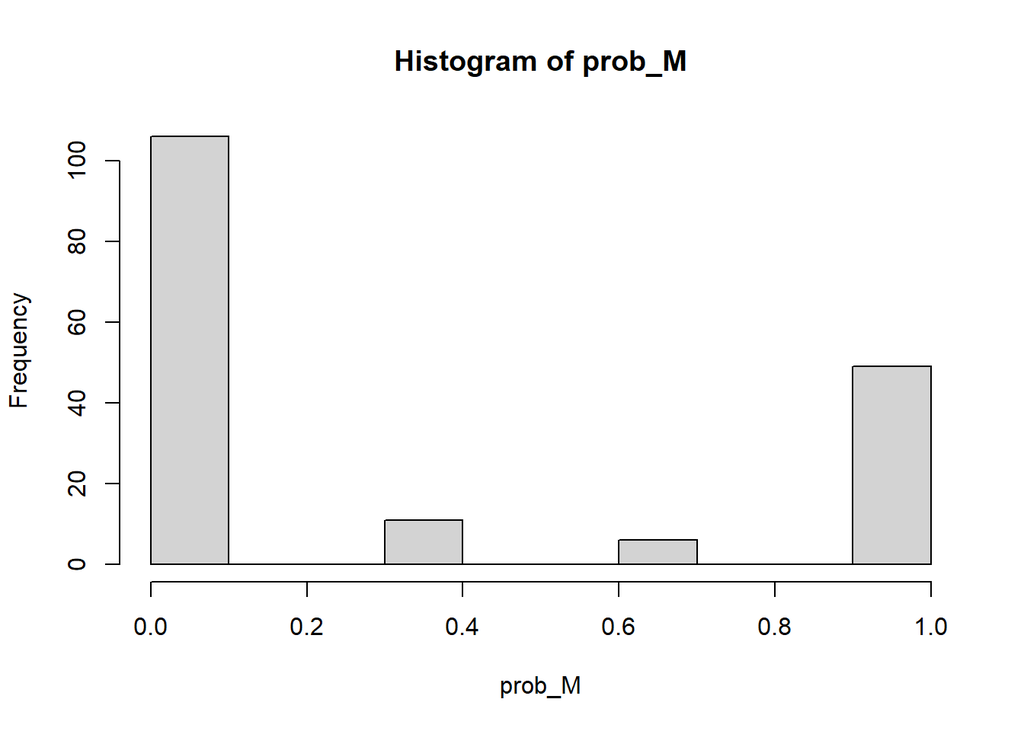

```r
hist(prob_M)
```

Roc Curve:

```r
roc_obj.knn<- roc(Ytest, prob_M)
```

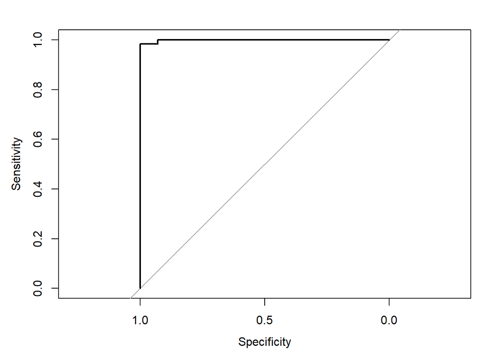

```r
plot(roc_obj.knn, type = 's')
```

```r
knn.AUC = auc(roc_obj.knn)
knn.AUC
```

```
## Area under the curve: 0.9891
```

Calibration Curve:

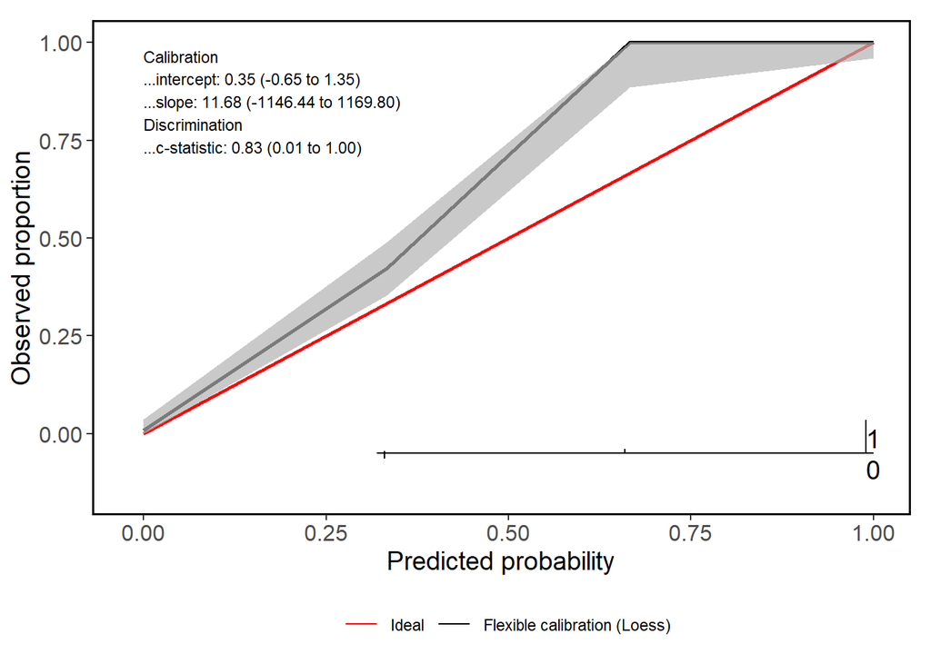

```
## Call:
## valProbggplot(p = prob_M, y = Ytest_numeric)
##
## A 95% confidence interval is given for the calibration intercept, calibration slope and c-statistic.
##
##          Dxy      C (ROC)           R2            D     D:Chi-sq          D:p
##  0.666666667  0.833333333  0.620040123  0.565716827 10.617186056  0.001120414
##            U     U:Chi-sq          U:p            Q        Brier    Intercept
##          Inf          Inf  0.000000000         -Inf  0.228758170  0.349415168
##        Slope         Emax Brier scaled         Eavg          ECI
## 11.677976970  0.548590453 -0.015086501  0.023088983  0.442946109
```

```r
knn.calplot<-valProbggplot(prob_M, Ytest_numeric)
knn.calplot
```

## Random Forest:

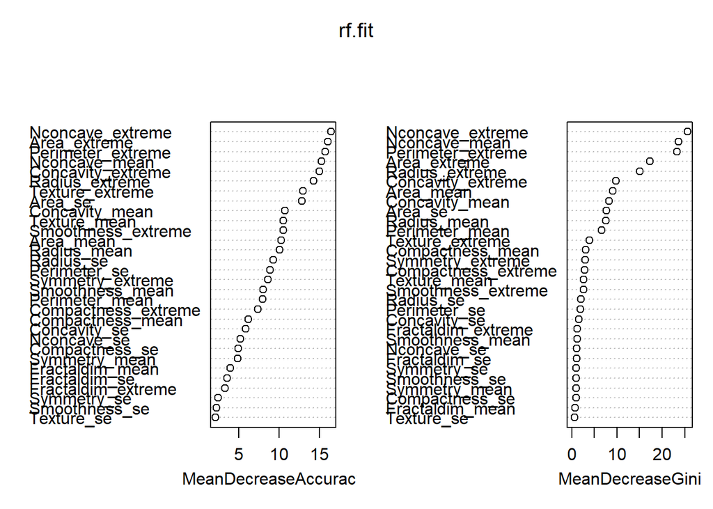

```r
#As now will be doing classification tasks so should be a factor.
rf.fit <- randomForest(as.factor(malignant) ~ ., data = BCW, subset =train.BCW, mtry = 5, importance = TRUE)
varImpPlot(rf.fit)
```

CV for m:

```r
set.seed(321)
mtry.values <- c(2, 5, 8, 10, 15)

mtry.errors <- sapply(mtry.values, function(m){
  fit <- randomForest(as.factor(malignant) ~., data = BCW[train.BCW, ], mtry = m, ntree = 500)
  return(fit$err.rate[500, "OOB"])
})

best.mtry <- mtry.values[which.min(mtry.errors)]
best.mtry
```

```
## [1] 8
```

Brier Score:

```r
rf.probs <- predict(rf.fit, newdata = BCW.test, type = "prob")
prob_M <- rf.probs[, 2]
rf_Brier <- brier_score(V2.test, prob_M)
rf_Brier
```

[output not shown]

Accuracy & Confusion Matrix:

```r
rf.class= rep(0, nrow(BCW.test))
rf.class[prob_M > 0.3] = 1
rf.class = factor(rf.class, levels = c(0,1))
table(rf.class, V2.test)
```

```
##         V2.test
## rf.class   0   1
##        0 105   0
##        1   8  59
```

```r
rf.Accuracy = mean(rf.class==V2.test)
rf.Accuracy
```

```
## [1] 0.9534884
```

Assessing Predictions:

```r
summary(prob_M)
```

```
##    Min. 1st Qu.  Median    Mean 3rd Qu.    Max.
##  0.0000  0.0080  0.0430  0.3623  0.9470  1.0000
```

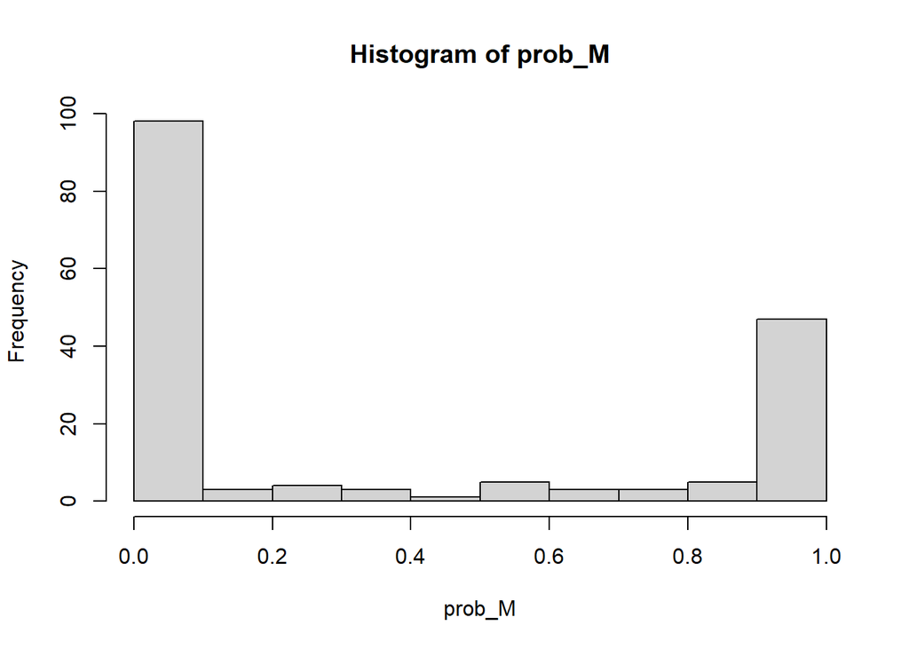

```r
hist(prob_M)
```

Roc Curve:

```r
roc_obj.rf<- roc(V2.test, prob_M)
```

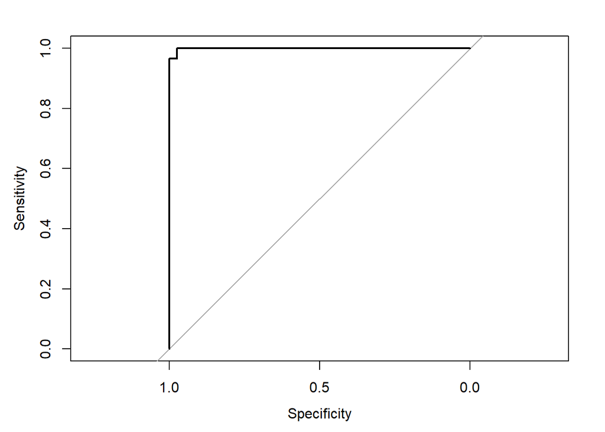

```r
plot(roc_obj.rf, type = 's')
```

```r
rf.AUC = auc(roc_obj.rf)
rf.AUC
```

[output not shown]

Calibration Curve:

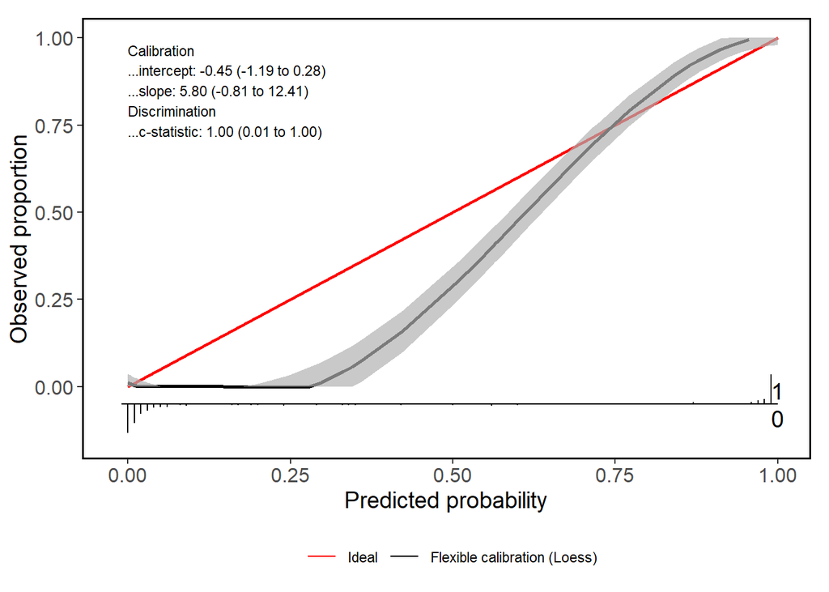

```
## Call:
## valProbggplot(p = prob_M, y = V2.test)
##
## A 95% confidence interval is given for the calibration intercept, calibration slope and c-statistic.
##
##           Dxy       C (ROC)            R2             D      D:Chi-sq
##  9.968421e-01  9.984211e-01  9.672327e-01  1.133140e+00  1.539739e+02
##           D:p             U      U:Chi-sq           U:p             Q
##  0.000000e+00  1.038703e-01  1.602249e+01  3.317108e-04  1.029270e+00
##         Brier     Intercept         Slope          Emax  Brier scaled
##  2.382418e-02 -4.539716e-01  5.803427e+00  4.023425e-01  8.942831e-01
##          Eavg           ECI
##  4.499200e-02  6.481701e-01
```

```r
rf.calplot<-valProbggplot(prob_M, V2.test)
rf.calplot
```